# Deep Learning Homework 6 (Spring 2023)

This code is provided for Deep Learning class (601.482/682) Homework 6. For ease of implementation, we recommend working entire in Google Colaboratory.

@Copyright Cong Gao, the Johns Hopkins University, cgao11@jhu.edu. Modifications made by Hongtao Wu, Suzanna Sia, Hao Ding, Keith Harrigian, and Yiqing Shen.

### Imports

```python
## Mount Google Drive Data (If using Google Colaboratory)
try:
    from google.colab import drive
    drive.mount('/content/gdrive')
except:
    print("Mounting Failed.")
```

```python
## Standard Library
import os
import json

## External Libraries
import numpy as np
import torch
import torch.nn as nn
from torchvision import transforms
from torch.autograd import Variable
import torch.nn.functional as functional
from torch.utils.data import Dataset, DataLoader
from skimage import io
import matplotlib.pyplot as plt
```

# Problem 1: Unsupervised Pre-training

### Training Hyperparameters

These are recommended hyperparameters - please feel free to use what works for you. Batch size can be changed if it does not match your memory, please state your batch step_size in your report.

Dataset is available at: https://livejohnshopkins-my.sharepoint.com/:u:/g/personal/yshen92_jh_edu/EcTxWAXsAhtDiv3vUxCTF8gBgAARCUvvKthb3s-pEExyMg

```python
from google.colab import drive
drive.mount('/content/drive')
```

```python
## Batch Size
train_batch_size = 10
validation_batch_size = 10

## Learning Rate
learning_rate = 0.001

# Epochs (Consider setting high and implementing early stopping)
num_epochs = 200
```

```python
# from google.colab import drive
# drive.flush_and_unmount()
# drive.mount('/content/gdrive', force_remount=True)
```

```python
import os

# to check if the path already exist
if os.path.exists("/content/drive/MyDrive/HW6_data"):
    print("Directory exists. No need to unzip again.")
else:
    print("Directory not found. You might need to unzip again.")
```

```
Directory exists. No need to unzip again.
```

### Data Paths

```python
# import zipfile

# with zipfile.ZipFile(data_dir, 'r') as zip_ref:
#     zip_ref.extractall("/content/gdrive/MyDrive/")
```

```python
# General Data Directory ##TODO: Please fill in the appropriate directory
# data_dir = "/content/gdrive/MyDrive/hw6_data.zip"
data_dir = '/content/drive/MyDrive/HW6_data'

## Segmentation + Colorization Paths
segmentation_data_dir = f"{data_dir}/segmentation/"
colorization_data_dir = f"{data_dir}/colorization/"

# Mask JSON
mask_json = f"{data_dir}/mapping.json"
```

```python
segmentation_data_dir
```

```
'/content/drive/MyDrive/HW6_data/segmentation/'
```

### Data Loaders

We have provided you with some preprocessing code for the images but you should feel free to modify the class however you please to support your training schema. In the very least, you will have to modify the dataloader to support loading of the colorization dataset.

```python
## Image Transforms
img_transform = transforms.Compose([
        transforms.ToTensor(),
])

## Image Dataloader
class ImageDataset(Dataset):

    """
    ImageDataset
    """

    def __init__(self,
                 input_dir,
                 op,
                 mask_json_path,
                 transforms=None,
                 is_colorization = False):
        """
        ##TODO: Add support for colorization dataset

        Args:
            input_dir (str): Path to either colorization or segmentation directory
            op (str): One of "train", "val", or "test" signifying the desired split
            mask_json_path (str): Path to mapping.json file
            transforms (list or None): Image transformations to apply upon loading.
        """
        self.transform = transforms
        self.op = op
        # Set the colorization flag
        self.is_colorization = is_colorization
        with open(mask_json_path, 'r') as f:
            self.mask = json.load(f)
        self.mask_num = len(self.mask)  # There are 6 categories: grey, dark grey, and black
        self.mask_value = [int(value) for key, value in self.mask.items() if not key.startswith("_comment")]
        self.mask_value.sort()
        if self.is_colorization == False:
            if self.op == 'train':
                self.data_dir = os.path.join(input_dir, 'train')
            elif self.op == 'val':
                self.data_dir = os.path.join(input_dir, 'validation')
            elif self.op == 'test':
                self.data_dir = os.path.join(input_dir, 'test')
        else:
            if self.op == 'train':
                self.data_dir = os.path.join(input_dir, 'train_cor')
            elif self.op == 'val':
                self.data_dir = os.path.join(input_dir, 'validation_cor')


    def __len__(self):
        """

        """
        return len(next(os.walk(self.data_dir))[1])

    def __getitem__(self,
                    idx):
        """

        """
        ## Load Image and Parse Properties
        if self.is_colorization == False:
            img_name = str(idx) + '_input.jpg'
            mask_name = str(idx) + '_mask.png'
        else:
            img_name = str(idx) + '_gray.jpg'
            mask_name = str(idx) + '_input.jpg'

        img = io.imread(os.path.join(self.data_dir, str(idx), img_name))
        mask = io.imread(os.path.join(self.data_dir, str(idx), mask_name))



        ## determine whether it is gray mask or RGB mask
        # there is no channel(c) for gray mask
        # c = 3 for RGB
        # h: height
        # w: width
        if len(mask.shape) == 2:
            h, w  = mask.shape
        elif len(mask.shape) == 3:
            h, w, c = mask.shape
        ## Convert grey-scale label to one-hot encoding
        if self.is_colorization == False:
            new_mask = np.zeros((h, w, self.mask_num))
            for idx in range(self.mask_num):
                #if the mask has 3 dimension use this code
                new_mask[:, :, idx] = mask[:,:,0] == self.mask_value[idx]
        else:
            new_mask = mask
            #if the mask has 1 dimension use the code below
            #new_mask[:, :, idx] = mask == self.mask_value[idx]
        ## Transform image and mask
        if self.transform:
            img, new_mask = self.img_transform(img, new_mask)
        # ## Use dictionary to output
        # sample = {'img': img, 'mask': mask}
        # return sample
        # 这里的mask已经转化为one-hot vector
        return img, new_mask

    def img_transform(self,
                      img,
                      mask):
        """

        """
        ## Apply Transformations to Image and Mask
        img = self.transform(img)
        mask = self.transform(mask)
        return img, mask

    def img_transform_single(self, img):
      return self.transform(img)
```

## Model Architecture

Finish building the U-net architecture below.

```python
## Functions for adding the convolution layer
def add_conv_stage(dim_in,
                   dim_out,
                   kernel_size=3,
                   stride=1,
                   padding=1,
                   bias=True,
                   useBN=True):
    """

    """
    # Use batch normalization
    if useBN:
        return nn.Sequential(
          nn.Conv2d(dim_in, dim_out, kernel_size=kernel_size, stride=stride, padding=padding, bias=bias),
          nn.BatchNorm2d(dim_out),
          nn.LeakyReLU(0.1),
          nn.Conv2d(dim_out, dim_out, kernel_size=kernel_size, stride=stride, padding=padding, bias=bias),
          nn.BatchNorm2d(dim_out),
          nn.LeakyReLU(0.1)
        )
    # No batch normalization
    else:
        return nn.Sequential(
          nn.Conv2d(dim_in, dim_out, kernel_size=kernel_size, stride=stride, padding=padding, bias=bias),
          nn.ReLU(),
          nn.Conv2d(dim_out, dim_out, kernel_size=kernel_size, stride=stride, padding=padding, bias=bias),
          nn.ReLU()
        )

## Upsampling
def upsample(ch_coarse,
             ch_fine):
    """

    """
    return nn.Sequential(
                    nn.ConvTranspose2d(ch_coarse, ch_fine, 4, 2, 1, bias=False),
                    nn.ReLU())


# U-Net
class UNET(nn.Module):

    """

    """
    def __init__(self, n_classes, input_channels_num = 3, useBN=True):
        """
        Args:
            n_classes (int): Number of classes
            useBN (bool): Turn Batch Norm on or off. (Hint: Using BatchNorm might help you achieve better performance.)
        """
        super(UNET, self).__init__()
        # Downgrade stages
        self.conv1 = add_conv_stage(input_channels_num, 32, useBN=useBN)
        self.conv2 = add_conv_stage(32, 64, useBN=useBN)
        self.conv3 = add_conv_stage(64, 128, useBN=useBN)
        self.conv4 = add_conv_stage(128, 256, useBN=useBN)
        # Upgrade stages
        self.conv3m = add_conv_stage(256, 128, useBN=useBN)
        self.conv2m = add_conv_stage(128,  64, useBN=useBN)
        self.conv1m = add_conv_stage( 64,  32, useBN=useBN)
        # Maxpool
        self.max_pool = nn.MaxPool2d(2)
        # Upsample layers
        self.upsample43 = upsample(256, 128)
        self.upsample32 = upsample(128,  64)
        self.upsample21 = upsample(64 ,  32)
        # weight initialization
        # You can have your own weight intialization. This is just an example.
        for m in self.modules():
            if isinstance(m, nn.Conv2d) or isinstance(m, nn.ConvTranspose2d):
                if m.bias is not None:
                    m.bias.data.zero_()
        #TODO: Design your last layer & activations
        self.final = nn.Conv2d(32, n_classes, 1)

        if n_classes == 3:
          self.final_act = nn.Sigmoid()
        else:
          self.final_act = nn.Softmax(dim = 1)


    def forward(self, x):
        """
        Forward pass
        """
        conv1_out = self.conv1(x)
        conv2_out = self.conv2(self.max_pool(conv1_out))
        conv3_out = self.conv3(self.max_pool(conv2_out))
        conv4_out = self.conv4(self.max_pool(conv3_out))

        conv4m_out_ = torch.cat((self.upsample43(conv4_out), conv3_out), 1)
        conv3m_out  = self.conv3m(conv4m_out_)

        conv3m_out_ = torch.cat((self.upsample32(conv3m_out), conv2_out), 1)
        conv2m_out  = self.conv2m(conv3m_out_)

        conv2m_out_ = torch.cat((self.upsample21(conv2m_out), conv1_out), 1)
        conv1m_out  = self.conv1m(conv2m_out_)

        #TODO: Design your last layer & activations
        final_out = self.final(conv1m_out)

        return self.final_act(final_out)
```

```python
device = torch.device('cuda' if torch.cuda.is_available() else 'cpu')
print(f"Current device: {device}")
```

```
Current device: cuda
```

```python
img = io.imread('/content/drive/MyDrive/HW6_data/colorization/validation_cor/1/1_gray.jpg')
print(img.shape)
```

```
(256, 320)
```

### DICE Score and DICE Loss

Finish implementing the DICE score function below and then write a Dice Loss function that you can use to update your model weights.

```python
##TODO: Finish implementing the multi-class DICE score function
def dice_score_image(prediction, target, n_classes):
    '''
      computer the mean dice score for a single image

      Reminders: A false positive is a result that indicates a given condition exists, when it does not
               A false negative is a test result that indicates that a condition does not hold, while in fact it does
      Args:
          prediction (tensor): predictied labels of the image
          target (tensor): ground truth of the image
          n_classes (int): number of classes

      Returns:
          m_dice (float): Mean dice score over classes
    '''
    ## Should test image one by one
    assert prediction.shape[0] == 1 #This line can not be deleted
    ## TODO: Compute Dice Score for Each Class. Compute Mean Dice Score over Classes.
    dice_scores = np.zeros(n_classes)
    target = torch.argmax(target, dim = 1)
    for cl in range(n_classes):
        pred_cl = (prediction == cl).float()
        true_cl = (target == cl).float()
        TP = torch.sum(pred_cl * true_cl)
        FP = torch.sum(pred_cl*(1 - true_cl))
        FN = torch.sum((1 - pred_cl) * true_cl)
        epsilon = 1e-7
        #When there is no ground truth of the class in this image
        #Give 1 dice score if False Positive pixel number is 0,
        #give 0 dice score if False Positive pixel number is not 0 (> 0).
        # if FP == 0:
        #   dice_scores.append(1.0)
        # else:
        #   dice_scores.append( (2 * TP + epsilon ) / (2 * TP + FP + FN + epsilon ) )

        if TP == 0 or FN == 0:
          dice_scores[cl] = 1.0 if FP == 0 else 0.0
        else:
          dice_scores[cl] = (2 * TP + epsilon) / (2 * TP + FP + FN + epsilon)

    return dice_scores.mean()



def dice_score_dataset(model, dataloader, num_classes, use_gpu=False):
    """
    Compute the mean dice score on a set of data.

    Note that multiclass dice score can be defined as the mean over classes of binary
    dice score. Dice score is computed per image. Mean dice score over the dataset is the dice
    score averaged across all images.

    Reminders: A false positive is a result that indicates a given condition exists, when it does not
               A false negative is a test result that indicates that a condition does not hold, while in fact it does

    Args:
        model (UNET class): Your trained model
        dataloader (DataLoader): Dataset for evaluation
        num_classes (int): Number of classes

    Returns:
        m_dice (float): Mean dice score over the input dataset
    """
    ## Number of Batches and Cache over Dataset
    n_batches = len(dataloader)
    scores = np.zeros(n_batches)
    ## Evaluate
    model.eval()
    idx = 0
    with torch.no_grad():
      for data in dataloader:
          ## Format Data
          img, target = data
          if use_gpu:
              img = img.cuda()
              target = target.cuda()
          ## Make Predictions
          out = model(img)
          n_classes = out.shape[1]
          prediction = torch.argmax(out, dim = 1)
          scores[idx] = dice_score_image(prediction, target, n_classes)
          idx += 1
    ## Average Dice Score Over Images
    m_dice = scores.mean()
    return m_dice


## TODO: Implement DICE loss,
#  It should conform to to how we computer the dice score.
class DICELoss(nn.Module):
    def __init__(self, n_classes):
      super(DICELoss, self).__init__()
      self.n_classes = n_classes
    def forward(self, prediction, target):
      #probs = torch.nn.functional.softmax(prediction, dim=1)
      probs = prediction
      dice_loss = 0.0
      for cl in range(self.n_classes):
        #pred_cl = (prediciton_classes == cl).float()
        # true_cl = (target == cl).float()
        pred_cl = probs[:, cl, :, :]
        true_cl = target[:, cl, :, :]
        error = 1e-7

        TP = torch.sum(pred_cl * true_cl)
        FP = torch.sum(pred_cl * (1 - true_cl))
        FN = torch.sum((1 - pred_cl) * true_cl)

        # Add dice loss for the class to the total dice loss
        dice_score = (2 * TP + error) / (2 * TP + FP + FN + error)
        dice_loss += 1 - dice_score
      return dice_loss / self.n_classes
```

```python
import random

def set_seed(seed_value):
    """Set seed for reproducibility."""
    random.seed(seed_value)
    np.random.seed(seed_value)
    torch.manual_seed(seed_value)
    torch.cuda.manual_seed(seed_value)
    torch.cuda.manual_seed_all(seed_value)
    torch.backends.cudnn.deterministic = True
    torch.backends.cudnn.benchmark = False
seed_value = 12345
set_seed(seed_value)
```

## Training Procedure (Segmentation)

```python
import copy
```

```
Start Training...

EPOCH 1 of 200

Epoch 1, Training loss: 0.8444, Validation Loss: 0.8090
Validation loss decreased, saving model...

EPOCH 2 of 200

Epoch 2, Training loss: 0.7666, Validation Loss: 0.8068
Validation loss decreased, saving model...

EPOCH 3 of 200

Epoch 3, Training loss: 0.7158, Validation Loss: 0.7713
Validation loss decreased, saving model...

EPOCH 4 of 200

Epoch 4, Training loss: 0.6663, Validation Loss: 0.7274
Validation loss decreased, saving model...

EPOCH 5 of 200

Epoch 5, Training loss: 0.6166, Validation Loss: 0.8029
Validation loss did not decrease, counter: 1/10

EPOCH 6 of 200

Epoch 6, Training loss: 0.6155, Validation Loss: 0.6704
Validation loss decreased, saving model...

EPOCH 7 of 200

Epoch 7, Training loss: 0.5525, Validation Loss: 0.6612
Validation loss decreased, saving model...

EPOCH 8 of 200

Epoch 8, Training loss: 0.5449, Validation Loss: 0.6834
```

[output cut: 146 more lines]

```

EPOCH 38 of 200

Epoch 38, Training loss: 0.3878, Validation Loss: 0.6011
Validation loss did not decrease, counter: 8/10

EPOCH 39 of 200

Epoch 39, Training loss: 0.3802, Validation Loss: 0.6007
Validation loss did not decrease, counter: 9/10

EPOCH 40 of 200

Epoch 40, Training loss: 0.3659, Validation Loss: 0.6007
Validation loss did not decrease, counter: 10/10
```

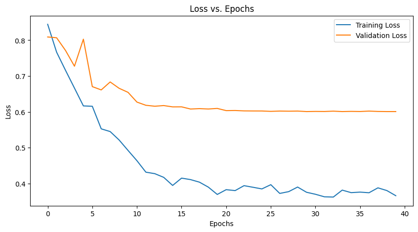

```python
## Initialize your unet
n_classes = len(json.load(open(mask_json)))
model = UNET(n_classes)
device = torch.device('cuda' if torch.cuda.is_available() else 'cpu')
model = model.to(device)

## Initialize Dataloaders
train_dataset=ImageDataset(input_dir=segmentation_data_dir, op="train", mask_json_path=mask_json, transforms=img_transform, is_colorization = False)
validation_dataset=ImageDataset(input_dir=segmentation_data_dir, op="val", mask_json_path=mask_json, transforms=img_transform, is_colorization = False)
test_dataset=ImageDataset(input_dir=segmentation_data_dir, op="test", mask_json_path=mask_json, transforms=img_transform, is_colorization = False)
train_dataloader = DataLoader(train_dataset, batch_size=train_batch_size, shuffle=True)
validation_dataloader = DataLoader(validation_dataset, batch_size=validation_batch_size, shuffle=False)
test_dataloader = DataLoader(test_dataset, batch_size=1, shuffle=False)
## Initialize Optimizer and Learning Rate Scheduler
optimizer = torch.optim.Adam(model.parameters(),lr=learning_rate)
scheduler = torch.optim.lr_scheduler.StepLR(optimizer, step_size=10, gamma=0.1)

# implement early stopping
patience = 10
best_val_loss = float('inf')
counter_early_stop = 0
early_stop = False
training_loss_values = []
validation_loss_values = []
print("Start Training...")
for epoch in range(num_epochs):
    ########################### Training #####################################
    print("\nEPOCH " +str(epoch+1)+" of "+str(num_epochs)+"\n")
    # TODO: Design your own training section
    model.train()
    train_loss = 0.0
    for images, masks in train_dataloader:
      images = images.to(device)
      masks = masks.to(device)

      optimizer.zero_grad()
      outputs = model(images)
      # print(outputs.requires_grad)
      loss = DICELoss(n_classes)(outputs, masks)
      loss.backward()
      optimizer.step()
      train_loss += loss.item()

    train_loss = train_loss / len(train_dataloader)
    training_loss_values.append(train_loss)

    ########################### Validation #####################################
    # TODO: Design your own validation section
    model.eval()
    val_loss = 0.0
    with torch.no_grad():
        for images, masks in validation_dataloader:
            images = images.to(device)
            masks = masks.to(device)
            outputs = model(images)
            # probs = torch.softmax(outputs, dim = 1)
            loss = DICELoss(n_classes).forward(outputs, masks)
            val_loss += loss.item()
    val_loss = val_loss / len(validation_dataloader)
    validation_loss_values.append(val_loss)
    print(f"Epoch {epoch+1}, Training loss: {train_loss:.4f}, Validation Loss: {val_loss:.4f}")
    if val_loss < best_val_loss:
        best_val_loss = val_loss
        best_model = copy.deepcopy(model.state_dict())  # Save the best model
        counter_early_stop = 0  # Reset counter
        print("Validation loss decreased, saving model...")
    else:
        counter_early_stop += 1
        print(f"Validation loss did not decrease, counter: {counter_early_stop}/{patience}")

    if counter_early_stop >= patience or epoch == num_epochs - 1:
        early_stop = True
        break


    scheduler.step()

plt.figure(figsize=(10, 5))
plt.plot(training_loss_values, label='Training Loss')
plt.plot(validation_loss_values, label='Validation Loss')
plt.xlabel('Epochs')
plt.ylabel('Loss')
plt.title('Loss vs. Epochs')
plt.legend()
plt.show()
```

```python
test_dice_score = dice_score_dataset(model, test_dataloader, n_classes, use_gpu=device.type == 'cuda')
print(f"Epoch {epoch+1}, DICE score on the test set: {test_dice_score:.4f}")
```

```
Epoch 40, DICE score on the test set: 0.5527
```

```python
from torchvision.transforms import functional as F

class RandomHorizontalFlip(object):

  def __init__(self, prob):
      self.prob = prob

  def __call__(self, img):
    if torch.rand(1).item() < self.prob:
        return torch.flip(img, [2])
    return img


class RandomRotation(object):

  def __init__(self, degrees):
      self.degrees = degrees

  def __call__(self, img):
    angle = torch.FloatTensor(1).uniform_(-self.degrees, self.degrees).item()
    return F.rotate(img, angle)


##prob = 0.25, degrees = 25, dice score = 0.5623



train_img_transform=  transforms.Compose([
      transforms. ToTensor (),
      RandomHorizontalFlip (prob=0.25),
      RandomRotation (degrees=15),
])
```

```
Start Training...

EPOCH 1 of 200

Epoch 1, Training loss: 0.8672, Validation Loss: 0.8139
Validation loss decreased, saving model...

EPOCH 2 of 200

Epoch 2, Training loss: 0.8249, Validation Loss: 0.7752
Validation loss decreased, saving model...

EPOCH 3 of 200

Epoch 3, Training loss: 0.7948, Validation Loss: 0.7762
Validation loss did not decrease, counter: 1/10

EPOCH 4 of 200

Epoch 4, Training loss: 0.7779, Validation Loss: 0.7761
Validation loss did not decrease, counter: 2/10

EPOCH 5 of 200

Epoch 5, Training loss: 0.7647, Validation Loss: 0.7601
Validation loss decreased, saving model...

EPOCH 6 of 200

Epoch 6, Training loss: 0.7436, Validation Loss: 0.7867
Validation loss did not decrease, counter: 1/10

EPOCH 7 of 200

Epoch 7, Training loss: 0.7326, Validation Loss: 0.7897
Validation loss did not decrease, counter: 2/10

EPOCH 8 of 200

Epoch 8, Training loss: 0.7401, Validation Loss: 0.7948
```

[output cut: 121 more lines]

```

EPOCH 33 of 200

Epoch 33, Training loss: 0.6819, Validation Loss: 0.6715
Validation loss did not decrease, counter: 8/10

EPOCH 34 of 200

Epoch 34, Training loss: 0.6789, Validation Loss: 0.6708
Validation loss did not decrease, counter: 9/10

EPOCH 35 of 200

Epoch 35, Training loss: 0.6830, Validation Loss: 0.6717
Validation loss did not decrease, counter: 10/10
```

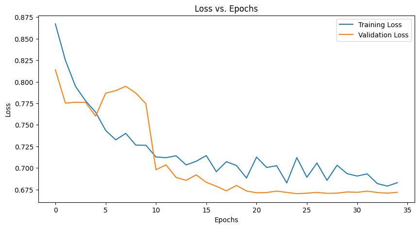

```python
## Initialize your unet
n_classes = len(json.load(open(mask_json)))
model = UNET(n_classes)
device = torch.device('cuda' if torch.cuda.is_available() else 'cpu')
model = model.to(device)

## Initialize Dataloaders
train_dataset=ImageDataset(input_dir=segmentation_data_dir, op="train", mask_json_path=mask_json, transforms=train_img_transform)
validation_dataset=ImageDataset(input_dir=segmentation_data_dir, op="val", mask_json_path=mask_json, transforms=img_transform)
test_dataset=ImageDataset(input_dir=segmentation_data_dir, op="test", mask_json_path=mask_json, transforms=img_transform)
train_dataloader = DataLoader(train_dataset, batch_size=train_batch_size, shuffle=True)
validation_dataloader = DataLoader(validation_dataset, batch_size=validation_batch_size, shuffle=False)
test_dataloader = DataLoader(test_dataset, batch_size=1, shuffle=False)
## Initialize Optimizer and Learning Rate Scheduler
optimizer = torch.optim.Adam(model.parameters(),lr=learning_rate)
scheduler = torch.optim.lr_scheduler.StepLR(optimizer, step_size=10, gamma=0.1)

# implement early stopping
patience = 10  # How many epochs to wait after last time validation loss improved.
best_val_loss = float('inf')
counter_early_stop = 0
early_stop = False
training_loss_values = []
validation_loss_values = []
print("Start Training...")
for epoch in range(num_epochs):
    ########################### Training #####################################
    print("\nEPOCH " +str(epoch+1)+" of "+str(num_epochs)+"\n")
    # TODO: Design your own training section
    model.train()
    train_loss = 0.0

    for images, masks in train_dataloader:

      # if torch.rand(1).item() < 0.5:
      #   images = torch.flip(images, [2])
      #   masks = torch.flip(masks, [2])
      # if torch.rand(1).item() < 0.5:
      #   images = torch.flip(images, [3])
      #   masks = torch.flip(masks, [3])


      images = images.to(device)
      masks = masks.to(device)
      optimizer.zero_grad()
      outputs = model(images)
      # print(outputs.requires_grad)
      loss = DICELoss(n_classes)(outputs, masks)
      loss.backward()
      optimizer.step()
      train_loss += loss.item()

    train_loss = train_loss / len(train_dataloader)
    training_loss_values.append(train_loss)

    ########################### Validation #####################################
    # TODO: Design your own validation section
    model.eval()
    val_loss = 0.0
    with torch.no_grad():
        for images, masks in validation_dataloader:
            images = images.to(device)
            masks = masks.to(device)
            outputs = model(images)
            # probs = torch.softmax(outputs, dim = 1)
            loss = DICELoss(n_classes).forward(outputs, masks)
            val_loss += loss.item()
    val_loss = val_loss / len(validation_dataloader)
    validation_loss_values.append(val_loss)
    print(f"Epoch {epoch+1}, Training loss: {train_loss:.4f}, Validation Loss: {val_loss:.4f}")
    if val_loss < best_val_loss:
        best_val_loss = val_loss
        best_model = copy.deepcopy(model.state_dict())  # Save the best model
        counter_early_stop = 0  # Reset counter
        print("Validation loss decreased, saving model...")
    else:
        counter_early_stop += 1
        print(f"Validation loss did not decrease, counter: {counter_early_stop}/{patience}")

    if counter_early_stop >= patience or epoch == num_epochs -1:
        early_stop = True
        break


    scheduler.step()

plt.figure(figsize=(10, 5))
plt.plot(training_loss_values, label='Training Loss')
plt.plot(validation_loss_values, label='Validation Loss')
plt.xlabel('Epochs')
plt.ylabel('Loss')
plt.title('Loss vs. Epochs')
plt.legend()
plt.show()
```

```python
test_dice_score = dice_score_dataset(model, test_dataloader, n_classes, use_gpu=device.type == 'cuda')
print(f"Epoch {epoch+1}, DICE score on the test set: {test_dice_score:.4f}")
```

```
Epoch 35, DICE score on the test set: 0.4572
```

## Training Procedure: Colorization Pre-training

Complete the rest of this problem in the cells below.

```python
## Batch Size
train_batch_size = 30
validation_batch_size = 30

## Learning Rate
learning_rate = 0.001

# Epochs (Consider setting high and implementing early stopping)
num_epochs = 200
```

```python
## Image Transforms
img_transform = transforms.Compose([
        transforms.ToTensor(),
])

## Image Dataloader
class ImageDataset(Dataset):

    """
    ImageDataset
    """

    def __init__(self,
                 input_dir,
                 op,
                 mask_json_path,
                 transforms=None,
                 is_colorization = False):
        """
        ##TODO: Add support for colorization dataset

        Args:
            input_dir (str): Path to either colorization or segmentation directory
            op (str): One of "train", "val", or "test" signifying the desired split
            mask_json_path (str): Path to mapping.json file
            transforms (list or None): Image transformations to apply upon loading.
        """
        self.transform = transforms
        self.op = op
        # Set the colorization flag
        self.is_colorization = is_colorization
        with open(mask_json_path, 'r') as f:
            self.mask = json.load(f)
        self.mask_num = len(self.mask)  # There are 6 categories: grey, dark grey, and black
        self.mask_value = [int(value) for key, value in self.mask.items() if not key.startswith("_comment")]
        self.mask_value.sort()
        if self.is_colorization == False:
            if self.op == 'train':
                self.data_dir = os.path.join(input_dir, 'train')
            elif self.op == 'val':
                self.data_dir = os.path.join(input_dir, 'validation')
            elif self.op == 'test':
                self.data_dir = os.path.join(input_dir, 'test')
        else:
            if self.op == 'train':
                self.data_dir = os.path.join(input_dir, 'train_cor')
            elif self.op == 'val':
                self.data_dir = os.path.join(input_dir, 'validation_cor')

    def __len__(self):
        if self.op == 'train':
            return 1584
        elif self.op == 'val':
            return 50
        else:
            raise ValueError("Invalid split option: {}".format(self.op))


    def __getitem__(self,
                    idx):
        """

        """
        ## Load Image and Parse Properties
        if self.is_colorization == False:
            img_name = str(idx) + '_input.jpg'
            mask_name = str(idx) + '_mask.png'
        else:
            img_name = str(idx) + '_gray.jpg'
            mask_name = str(idx) + '_input.jpg'

        img = io.imread(os.path.join(self.data_dir, str(idx), img_name))
        mask = io.imread(os.path.join(self.data_dir, str(idx), mask_name))



        ## determine whether it is gray mask or RGB mask
        # there is no channel(c) for gray mask
        # c = 3 for RGB
        # h: height
        # w: width
        if len(mask.shape) == 2:
            h, w  = mask.shape
        elif len(mask.shape) == 3:
            h, w, c = mask.shape
        ## Convert grey-scale label to one-hot encoding
        if self.is_colorization == False:
            new_mask = np.zeros((h, w, self.mask_num))
            for idx in range(self.mask_num):
                #if the mask has 3 dimension use this code
                new_mask[:, :, idx] = mask[:,:,0] == self.mask_value[idx]
        else:
            new_mask = mask
            #if the mask has 1 dimension use the code below
            #new_mask[:, :, idx] = mask == self.mask_value[idx]
        ## Transform image and mask
        if self.transform:
            img, new_mask = self.img_transform(img, new_mask)
        # ## Use dictionary to output
        # sample = {'img': img, 'mask': mask}
        # return sample
        # 这里的mask已经转化为one-hot vector
        return img, new_mask

    def img_transform(self,
                      img,
                      mask):
        """

        """
        ## Apply Transformations to Image and Mask
        img = self.transform(img)
        mask = self.transform(mask)
        return img, mask

    def img_transform_single(self, img):
      return self.transform(img)
```

```
Start Training...

EPOCH 1 of 200

Epoch 1, Training loss: 0.0099, Validation Loss: 0.0049
Validation loss decreased, saving model...

EPOCH 2 of 200

Epoch 2, Training loss: 0.0017, Validation Loss: 0.0019
Validation loss decreased, saving model...

EPOCH 3 of 200

Epoch 3, Training loss: 0.0012, Validation Loss: 0.0020
Validation loss did not decrease, counter: 1/5

EPOCH 4 of 200

Epoch 4, Training loss: 0.0011, Validation Loss: 0.0021
Validation loss did not decrease, counter: 2/5

EPOCH 5 of 200

Epoch 5, Training loss: 0.0009, Validation Loss: 0.0015
Validation loss decreased, saving model...

EPOCH 6 of 200

Epoch 6, Training loss: 0.0009, Validation Loss: 0.0017
Validation loss did not decrease, counter: 1/5

EPOCH 7 of 200

Epoch 7, Training loss: 0.0008, Validation Loss: 0.0023
Validation loss did not decrease, counter: 2/5

EPOCH 8 of 200

Epoch 8, Training loss: 0.0008, Validation Loss: 0.0024
```

[output cut: 101 more lines]

```

EPOCH 29 of 200

Epoch 29, Training loss: 0.0005, Validation Loss: 0.0012
Validation loss did not decrease, counter: 3/5

EPOCH 30 of 200

Epoch 30, Training loss: 0.0005, Validation Loss: 0.0012
Validation loss did not decrease, counter: 4/5

EPOCH 31 of 200

Epoch 31, Training loss: 0.0005, Validation Loss: 0.0012
Validation loss did not decrease, counter: 5/5
```

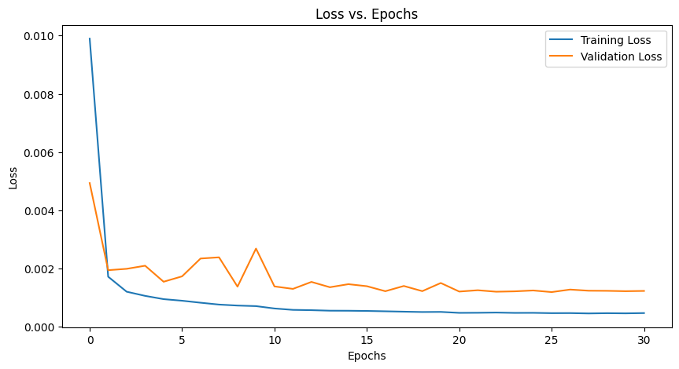

```python
from torch.optim.lr_scheduler import StepLR
from torch.nn import MSELoss

# for colorization task, we expect the output channel(n_classes) = 3
model = UNET(input_channels_num= 1,n_classes = 3)
device = torch.device('cuda' if torch.cuda.is_available() else 'cpu')
model = model.to(device)

## Initialize Dataloaders
train_dataset=ImageDataset(input_dir=colorization_data_dir, op="train", mask_json_path=mask_json, transforms=img_transform, is_colorization = True)
validation_dataset=ImageDataset(input_dir=colorization_data_dir, op="val", mask_json_path=mask_json, transforms=img_transform, is_colorization = True)
train_dataloader = DataLoader(train_dataset, batch_size=train_batch_size, shuffle=True)
validation_dataloader = DataLoader(validation_dataset, batch_size=validation_batch_size, shuffle=False)
## Initialize Optimizer and Learning Rate Scheduler
optimizer = torch.optim.Adam(model.parameters(),lr=learning_rate)
scheduler = torch.optim.lr_scheduler.StepLR(optimizer, step_size=10, gamma=0.1)
criterion = nn.MSELoss()

patience = 5  # How many epochs to wait after last time validation loss improved.
best_val_loss = float('inf')
counter_early_stop = 0
early_stop = False
training_loss_values = []
validation_loss_values = []
print("Start Training...")
for epoch in range(num_epochs):
    ########################### Training #####################################
    print("\nEPOCH " +str(epoch+1)+" of "+str(num_epochs)+"\n")
    # TODO: Design your own training section
    model.train()
    train_loss = 0.0
    for images, mask in train_dataloader:  # No masks needed for colorization
      images = images.to(device)
      mask = mask.to(device)

      outputs = model(images)
      loss = criterion(outputs, mask)

      optimizer.zero_grad()
      loss.backward()
      optimizer.step()
      train_loss += loss.item()

    train_loss = train_loss / len(train_dataloader)
    training_loss_values.append(train_loss)

    ########################### Validation #####################################
    # TODO: Design your own validation section
    model.eval()
    val_loss = 0.0
    with torch.no_grad():
        for images, masks in validation_dataloader:
            images = images.to(device)
            masks = masks.to(device)

            outputs = model(images)
            loss = criterion(outputs, masks)

            val_loss += loss.item()

    val_loss = val_loss / len(validation_dataloader)
    validation_loss_values.append(val_loss)
    print(f"Epoch {epoch+1}, Training loss: {train_loss:.4f}, Validation Loss: {val_loss:.4f}")

    scheduler.step()
    if val_loss < best_val_loss:
        best_val_loss = val_loss
        best_model = copy.deepcopy(model.state_dict())  # Save the best model
        counter_early_stop = 0  # Reset counter
        print("Validation loss decreased, saving model...")
    else:
        counter_early_stop += 1
        print(f"Validation loss did not decrease, counter: {counter_early_stop}/{patience}")

    if counter_early_stop >= patience or epoch == num_epochs -1:
        early_stop = True
        break

torch.save(model.state_dict(), data_dir + '/model.pth')

plt.figure(figsize=(10, 5))
plt.plot(training_loss_values, label='Training Loss')
plt.plot(validation_loss_values, label='Validation Loss')
plt.xlabel('Epochs')
plt.ylabel('Loss')
plt.title('Loss vs. Epochs')
plt.legend()
plt.show()
```

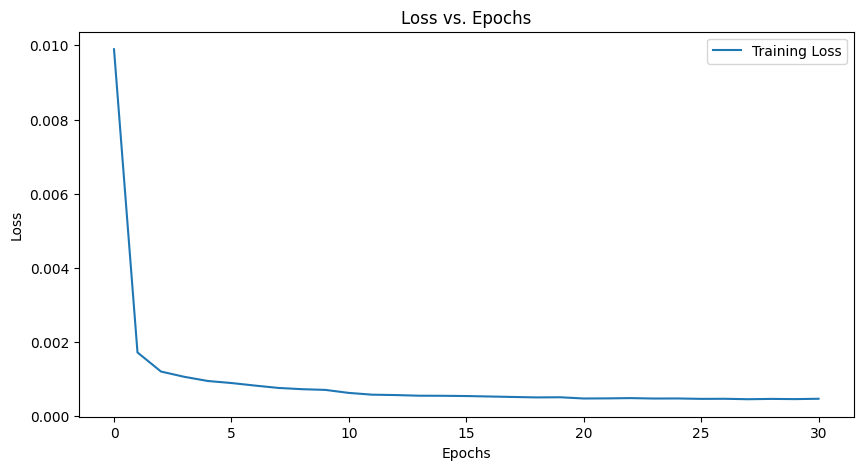

```python
plt.figure(figsize=(10, 5))
plt.plot(training_loss_values, label='Training Loss')
plt.xlabel('Epochs')
plt.ylabel('Loss')
plt.title('Loss vs. Epochs')
plt.legend()
plt.show()
```

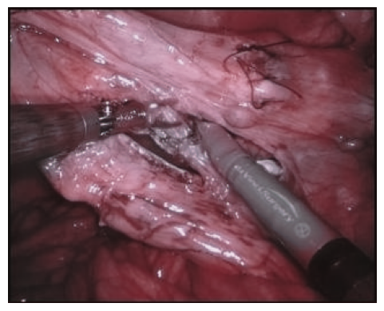

```python
train_batch_size = 10
validation_batch_size = 10

train_dataset = ImageDataset(input_dir=colorization_data_dir, op="train", mask_json_path=mask_json, transforms=img_transform, is_colorization=True)
validation_dataset = ImageDataset(input_dir=colorization_data_dir, op="val", mask_json_path=mask_json, transforms=img_transform, is_colorization=True)
train_dataloader = DataLoader(train_dataset, batch_size=train_batch_size, shuffle=True)
validation_dataloader = DataLoader(validation_dataset, batch_size=validation_batch_size, shuffle=False)

device = torch.device('cuda' if torch.cuda.is_available() else 'cpu')
model = model.to(device)
outputs = model(next(iter(validation_dataloader))[0].to(device))

out_np = outputs[0].detach().cpu().numpy()

out_np = (out_np * 255).astype(np.uint8)

out_np = np.transpose(out_np, (1, 2, 0))

plt.imshow(out_np)
plt.axis('off')
plt.show()
```

```python
## Batch Size
train_batch_size = 10
validation_batch_size = 10

## Learning Rate
learning_rate = 0.001

# Epochs (Consider setting high and implementing early stopping)
num_epochs = 200
```

```
Start Training...

EPOCH 1 of 200

Epoch 1, Training loss: 0.8570, Validation Loss: 0.7950
Validation loss decreased, saving model...

EPOCH 2 of 200

Epoch 2, Training loss: 0.7780, Validation Loss: 0.7806
Validation loss decreased, saving model...

EPOCH 3 of 200

Epoch 3, Training loss: 0.7267, Validation Loss: 0.7414
Validation loss decreased, saving model...

EPOCH 4 of 200

Epoch 4, Training loss: 0.6772, Validation Loss: 0.7437
Validation loss did not decrease, counter: 1/10

EPOCH 5 of 200

Epoch 5, Training loss: 0.6445, Validation Loss: 0.7653
Validation loss did not decrease, counter: 2/10

EPOCH 6 of 200

Epoch 6, Training loss: 0.6176, Validation Loss: 0.7096
Validation loss decreased, saving model...

EPOCH 7 of 200

Epoch 7, Training loss: 0.5733, Validation Loss: 0.6698
Validation loss decreased, saving model...

EPOCH 8 of 200

Epoch 8, Training loss: 0.5500, Validation Loss: 0.6807
```

[output cut: 201 more lines]

```

EPOCH 49 of 200

Epoch 49, Training loss: 0.3939, Validation Loss: 0.6078
Validation loss did not decrease, counter: 8/10

EPOCH 50 of 200

Epoch 50, Training loss: 0.4160, Validation Loss: 0.6082
Validation loss did not decrease, counter: 9/10

EPOCH 51 of 200

Epoch 51, Training loss: 0.3947, Validation Loss: 0.6074
Validation loss did not decrease, counter: 10/10
```

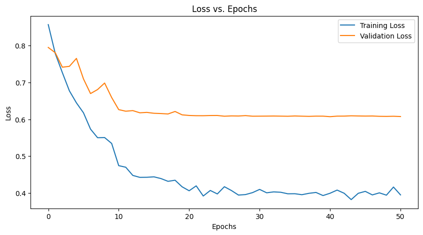

```python
pretrain_model_path = torch.load(data_dir + '/model.pth')
n_classes = len(json.load(open(mask_json)))
model = UNET(n_classes)
device = torch.device('cuda' if torch.cuda.is_available() else 'cpu')
model = model.to(device)

model_dict = model.state_dict()

pretrain_dict = {k: v for k, v in pretrain_model_path.items() if k in model_dict and model_dict[k].size() == v.size()}
model_dict.update(pretrain_dict)

model.load_state_dict(model_dict)



## Initialize Dataloaders
train_dataset=ImageDataset(input_dir=segmentation_data_dir, op="train", mask_json_path=mask_json, transforms=img_transform, is_colorization = False)
validation_dataset=ImageDataset(input_dir=segmentation_data_dir, op="val", mask_json_path=mask_json, transforms=img_transform, is_colorization = False)
test_dataset=ImageDataset(input_dir=segmentation_data_dir, op="test", mask_json_path=mask_json, transforms=img_transform, is_colorization = False)
train_dataloader = DataLoader(train_dataset, batch_size=train_batch_size, shuffle=True)
validation_dataloader = DataLoader(validation_dataset, batch_size=validation_batch_size, shuffle=False)
test_dataloader = DataLoader(test_dataset, batch_size=1, shuffle=False)
## Initialize Optimizer and Learning Rate Scheduler
optimizer = torch.optim.Adam(model.parameters(),lr=learning_rate)
scheduler = torch.optim.lr_scheduler.StepLR(optimizer, step_size=10, gamma=0.1)

# implement early stopping
patience = 10
best_val_loss = float('inf')
counter_early_stop = 0
early_stop = False
training_loss_values = []
validation_loss_values = []
print("Start Training...")
for epoch in range(num_epochs):
    ########################### Training #####################################
    print("\nEPOCH " +str(epoch+1)+" of "+str(num_epochs)+"\n")
    # TODO: Design your own training section
    model.train()
    train_loss = 0.0
    for images, masks in train_dataloader:
      images = images.to(device)
      masks = masks.to(device)

      optimizer.zero_grad()
      outputs = model(images)
      # print(outputs.requires_grad)
      loss = DICELoss(n_classes)(outputs, masks)
      loss.backward()
      optimizer.step()
      train_loss += loss.item()

    train_loss = train_loss / len(train_dataloader)
    training_loss_values.append(train_loss)

    ########################### Validation #####################################
    # TODO: Design your own validation section
    model.eval()
    val_loss = 0.0
    with torch.no_grad():
        for images, masks in validation_dataloader:
            images = images.to(device)
            masks = masks.to(device)
            outputs = model(images)
            # probs = torch.softmax(outputs, dim = 1)
            loss = DICELoss(n_classes).forward(outputs, masks)
            val_loss += loss.item()
    val_loss = val_loss / len(validation_dataloader)
    validation_loss_values.append(val_loss)
    print(f"Epoch {epoch+1}, Training loss: {train_loss:.4f}, Validation Loss: {val_loss:.4f}")
    if val_loss < best_val_loss:
        best_val_loss = val_loss
        best_model = copy.deepcopy(model.state_dict())  # Save the best model
        counter_early_stop = 0  # Reset counter
        print("Validation loss decreased, saving model...")
    else:
        counter_early_stop += 1
        print(f"Validation loss did not decrease, counter: {counter_early_stop}/{patience}")

    if counter_early_stop >= patience or epoch == num_epochs - 1:
        early_stop = True
        break


    scheduler.step()

plt.figure(figsize=(10, 5))
plt.plot(training_loss_values, label='Training Loss')
plt.plot(validation_loss_values, label='Validation Loss')
plt.xlabel('Epochs')
plt.ylabel('Loss')
plt.title('Loss vs. Epochs')
plt.legend()
plt.show()
```

```python
test_dice_score = dice_score_dataset(model, test_dataloader, n_classes, use_gpu=device.type == 'cuda')
print(f"Epoch {epoch+1}, DICE score on the test set: {test_dice_score:.4f}")
```

```
Epoch 51, DICE score on the test set: 0.4896
```

# Problem 2: Transfer Learning

### Imports

```python
## Import VGG and FashionMNIST
import torch
from torchvision.models import vgg16
from torchvision.datasets import FashionMNIST
from torchvision import models, datasets, transforms
from torch.utils.data import DataLoader
from torch import nn
```

### Data Loading

```python
## Specify Batch Size
train_batch_size = 64
test_batch_size = 64

## Specify Image Transforms
img_transform = transforms.Compose([
    transforms.Resize((224,224)),
    transforms.Grayscale(num_output_channels= 3),
    transforms.ToTensor(),
    transforms.Normalize((0.5, 0.5, 0.5), (0.5, 0.5, 0.5))
])

## Download Datasets
train_data = FashionMNIST('./data', transform=img_transform, download=True, train=True)
test_data = FashionMNIST('./data', transform=img_transform, download=True, train=False)

## Initialize Dataloaders
training_dataloader = DataLoader(train_data, batch_size=train_batch_size, shuffle=True)
test_dataloader = DataLoader(test_data, batch_size=test_batch_size, shuffle=True)
```

### Model Initialization and Training/Fine-tuning

Complete the rest of the assignment in the notebook below.

```python
def init_random_vgg16():
    model = models.vgg16()
    model.to('cuda')
    return model


def finetune_vgg16():
    model = models.vgg16(pretrained=True)

    for param in model.features.parameters():
        param.requires_grad = False

    num_features = model.classifier[6].in_features
    # Freeze all but the last layer: randomly initialize the last layer of your network and fine-tune this.
    model.classifier[6] = nn.Linear(num_features, len(train_data.classes))

    model.to('cuda')

    return model
```

```python
# TODO: Define your training loop, loss function, and optimizer and train your models
def train_model(model, train_dataloader, criterion, optimizer, num_epochs=6):
    for epoch in range(num_epochs):
        model.train()
        running_loss = 0.0
        correct_predictions = 0

        for inputs, labels in train_dataloader:
            inputs, labels = inputs.to('cuda'), labels.to('cuda')
            optimizer.zero_grad()

            outputs = model(inputs)
            loss = criterion(outputs, labels)
            _, preds = torch.max(outputs, 1)

            loss.backward()
            optimizer.step()

            running_loss += loss.item() * inputs.size(0)
            correct_predictions += torch.sum(preds == labels.data)

        epoch_loss = running_loss / len(train_dataloader.dataset)
        epoch_acc = correct_predictions.double() / len(train_dataloader.dataset)

        print(f'Epoch {epoch + 1}/{num_epochs}, Loss: {epoch_loss:.4f}, Accuracy: {epoch_acc:.4f}')

    print('Training complete')
```

```python
def test_model(model, test_dataloader, criterion, optimizer, num_epochs=6):
        model.eval()
        running_loss = 0.0
        correct_predictions = 0

        for inputs, labels in test_dataloader:
            inputs, labels = inputs.to('cuda'), labels.to('cuda')
            with torch.no_grad():
                outputs = model(inputs)
                loss = criterion(outputs, labels)
                _, preds = torch.max(outputs, 1)

            running_loss += loss.item() * inputs.size(0)
            correct_predictions += torch.sum(preds == labels.data)

        epoch_loss = running_loss / len(test_dataloader.dataset)
        epoch_acc = correct_predictions.double() / len(test_dataloader.dataset)

        print(f'Test Loss: {epoch_loss:.4f}, Test Acc: {epoch_acc:.4f}')
```

```python
random_vgg16 = init_random_vgg16()
finetuned_vgg16 = finetune_vgg16()
criterion = nn.CrossEntropyLoss()
```

```python
device = torch.device('cuda' if torch.cuda.is_available() else 'cpu')
print(f"Current device: {device}")
```

```
Current device: cuda
```

```python
optimizer_random = torch.optim.Adam(random_vgg16.parameters(), lr=0.001)
train_model(random_vgg16, training_dataloader, criterion, optimizer_random, num_epochs=5)
```

[output not shown]

```python
test_model(random_vgg16, test_dataloader, criterion, optimizer_random, num_epochs=5)
```

```
Test Loss: 0.2340, Test Acc: 0.9156
```

```python
print(random_vgg16(next(iter(test_dataloader))[0].to(device)).shape)
print(next(iter(test_dataloader))[0].shape)
print(next(iter(training_dataloader))[0].shape)
```

```
torch.Size([64, 1000])
torch.Size([64, 3, 224, 224])
torch.Size([64, 3, 224, 224])
```

```python
optimizer_finetuned = torch.optim.Adam(finetuned_vgg16.classifier[6].parameters(), lr=0.001)
train_model(finetuned_vgg16, training_dataloader, criterion, optimizer_finetuned, num_epochs=5)
```

[output not shown]

```python
test_model(finetuned_vgg16, test_dataloader, criterion, optimizer_finetuned, num_epochs=5)
```

```
Test Loss: 0.4118, Test Acc: 0.8498
```